# Future of ggplot2 extenders

# Epic poems… + aes() + geom_?() + ggplyr::layers_wipe()

But allowing aesthetic mappings to be expressed independently, and given some extension, *greater* concision may actually possible. Via a conversational approach… Beyond ‘base’ ggplot2… let’s you keep the conversation going where train of thought is just one grammar move away…

No logical leaps!

[figure not shown]

[figure not shown]

Circlepack, swarm poem

Let’s have a look at “Visualizing Why Yesterdays Stock Market Reversal Was So Weird and Unnerving” by David Crowther. This is an ‘epic graphical poem’. And yet, the fact that it’s not making logical leaps means that we are often just a grammar of graphics ‘move’ away from the next plot that he builds.

https://sherwood.news/markets/visualizing-why-yesterdays-stock-market-reversal-was-so-weird-and-unnerving/

```r
# remotes::install_github("https://github.com/EvaMaeRey/ggplyr")
# remotes::install_github("https://github.com/EvaMaeRey/ggcirclepack")

# this block from an ellmerXgemini

library(tidyquant)
library(dplyr)
library(lubridate) # For today()

# --- 1. Define Parameters ---
symbol <- "^GSPC" # S&P 500 Yahoo Finance symbol
start_date <- "2015-01-01" # Corrected from 20215
end_date <- "2025-11-21"

# --- 2. Load Data ---
# tq_get fetches financial data
sp500_data <- tq_get(symbol,
                     get = "stock.prices", # Specify we want stock prices
                     from = start_date,
                     to = end_date)

# this block from an ellmerXgemini

library(tidyverse)
library(ggplyr)
library(ggcirclepack)

# tq_get fetches financial data
sp500_data <- tq_get(symbol,
                     get = "stock.prices", # Specify we want stock prices
                     from = start_date,
                     to = end_date)

sp_500_data_calcs <-
  sp500_data  |>
  mutate(
    year = year(date),
    return = (close - lag(close))/lag(close)*100,
    open_pct = (open - lag(close))/lag(close)*100,
    intraday_pct = 100*(close-open)/open,
    ind_yesterday = date == "2025-11-20"
         )

library(RColorBrewer)
library(tidyverse)
library(ggplyr) # hey
library(ggcirclepack)
library(RColorBrewer)

library(tidyverse)
library(ggcirclepack)
(theme_gray() +
    theme(palette.fill.discrete = brewer.pal(8, "Dark2")[c(1:8, 1:3)],
          palette.color.discrete = c("transparent", "magenta"),
          palette.fill.continuous = "viridis")
  ) |>
  theme_set()
sp_500_data_calcs |> head()
```

```
## # A tibble: 6 × 13
##   symbol date        open  high   low close     volume adjusted  year return
##   <chr>  <date>     <dbl> <dbl> <dbl> <dbl>      <dbl>    <dbl> <dbl>  <dbl>
## 1 ^GSPC  2015-01-02 2059. 2072. 2046. 2058. 2708700000    2058.  2015 NA
## 2 ^GSPC  2015-01-05 2054. 2054. 2017. 2021. 3799120000    2021.  2015 -1.83
## 3 ^GSPC  2015-01-06 2022. 2030. 1992. 2003. 4460110000    2003.  2015 -0.889
## 4 ^GSPC  2015-01-07 2006. 2030. 2006. 2026. 3805480000    2026.  2015  1.16
## 5 ^GSPC  2015-01-08 2031. 2064. 2031. 2062. 3934010000    2062.  2015  1.79
## 6 ^GSPC  2015-01-09 2063. 2064. 2038. 2045. 3364140000    2045.  2015 -0.840
## # ℹ 3 more variables: open_pct <dbl>, intraday_pct <dbl>, ind_yesterday <lgl>
```

```r
library(RColorBrewer)
```

| ggplot(sp_500_data_calcs) + |
| --- |
| aes(id = date) + |
| ggcirclepack::geom_circlepack() + |
| aes(color = ind_yesterday) + |
| aes(fill = as_factor(year)) + |
| coord_equal() + |
| aes(fill = return) + |
| scale_fill_gradient2(mid = "snow", low = "#410000", high = "darkblue") + |
| facet_wrap(~year) + |
| facet_null() + |
| ggplyr::data_filter(open_pct > 1) + |
| ggplyr::layers_wipe() + |
| aes(y = "All", x = open_pct) + |
| ggbeeswarm::geom_beeswarm(shape = 21) + |
| coord_cartesian() + |
| aes(size = I(5)) + |
| scale_color_manual(values = c("whitesmoke", "magenta")) + |
| aes(x = return) + |
| aes(y = "") + |
| facet_grid(rows = vars(year)) + |
| facet_null() + |
| aes(y = intraday_pct, x = open_pct) |

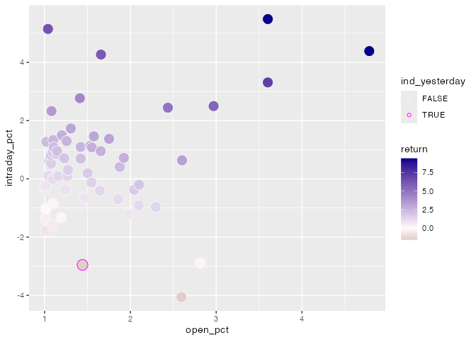

https://evamaerey.github.io/mytidytuesday/2025-11-24-s-and-p-since-2015/s-and-p-since-2015.html

Do we even have the tools for nearly verbatim recording of data analysis? Concise, *in-sequence*, trains-of-thought. *Transcription…*

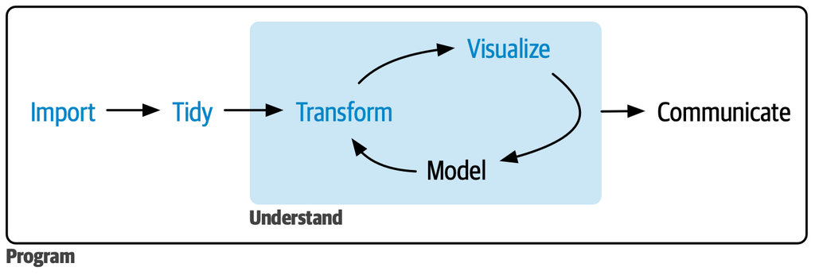

# Who are the ggplot2 extenders (in graphical poems?)

deserve bespoke vocab that allows us to write down statistical narrative elegantly!

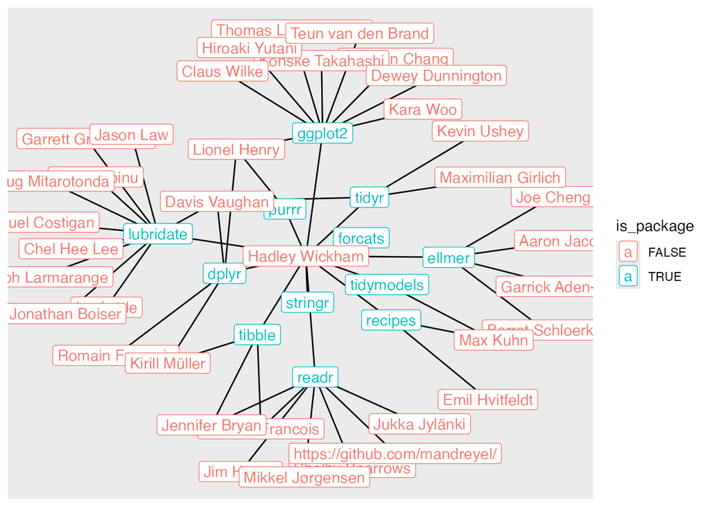

```r
library(tidyverse)
library(ggraph)

ggraph_to_threejs <- function(edgelist = package_author_edgelist,
                              plot = last_plot()){

  g <-  edgelist |> select(1:2) |> as.matrix() |>
    graph_from_edgelist()

  node_data <- layer_data(i = 2, plot = plot)

  graph_attr(g, "layout") <- NULL

  node_id <- V(g) |> names()

  joined <- tibble(node_id) |>
    left_join(node_data, by = "node_id")

  from_list <- edgelist |> pull(1)

  V(g)$size <- joined$size/3.66
  V(g)$shape <- joined$label
  V(g)$color <- joined$colour

  graphjs(g = g, bg = "gray10",
          showLabels = T,
          layout = list(
            layout_with_fr(g, dim = 3)),
                    main = "")

}

vct_packages <- c("dplyr", "ggplot2", "ellmer",
                        "tidyr", "tidymodels", "recipes",
                        "readr", "tibble", "stringr", "forcats",
                        "purrr", "lubridate")

# data cleaning
as_tibble(tools::CRAN_package_db()) |>
  filter(Package %in% vct_packages) |>
  mutate(Author = str_replace_all(Author, ' \\[|\\]', "*" )) |>
  select(Package, Author) |>
  mutate(Author = map(Author, ~ str_split_1(.x,"\n"))) |>
  unnest() |>
  mutate(Author = Author |> str_remove('\\*.+' )) |>
  mutate(Author = Author |> str_trim()) |>
  filter_out(Author |> str_detect("orcid.org")) |>
  filter_out(Author == "Posit Software, PBC") |>
  filter_out(Author == "Posit, PBC") ->
package_author_edgelist



theme_set(theme_gray())

# network visualization
package_author_edgelist |>
  tidygraph::as_tbl_graph() |>
  mutate(is_package = name %in% vct_packages) |>
  ggraph(layout = "kk") +
  geom_edge_link() +
  geom_node_label(aes(label = name,
                      node_id = name, # for conversion to threejs
                      color = is_package))
```

```r
package_author_edgelist |>
  distinct(Author) |>
  mutate(package = "Claude")
```

```
## # A tibble: 37 × 2
##    Author            package
##    <chr>             <chr>
##  1 Hadley Wickham    Claude
##  2 Romain François   Claude
##  3 Lionel Henry      Claude
##  4 Kirill Müller     Claude
##  5 Davis Vaughan     Claude
##  6 Joe Cheng         Claude
##  7 Aaron Jacobs      Claude
##  8 Garrick Aden-Buie Claude
##  9 Barret Schloerke  Claude
## 10 Winston Chang     Claude
## # ℹ 27 more rows
```

```r
library(threejs)
library(igraph)



ggraph_to_threejs(package_author_edgelist)
```

[interactive chart not shown]

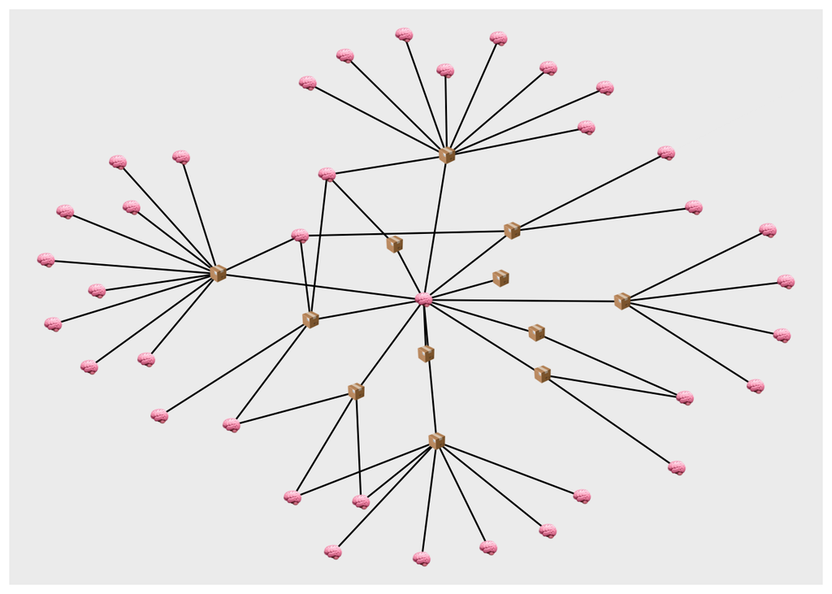

```r
ggplyr::last_plot_wipe_last() +
  geom_node_text(aes(
    node_id = name, # just for threejs
    label = is_package |> ifelse("📦", "🧠"),
    color = is_package |> ifelse("tan", "pink") |> I()))
```

```r
ggraph_to_threejs(package_author_edgelist)
```

[interactive chart not shown]

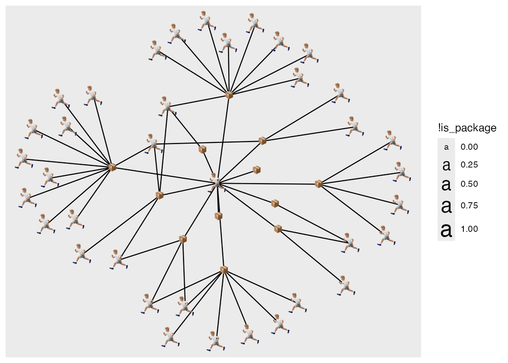

```r
ggplyr::last_plot_wipe_last() +
  geom_node_text(aes(
    size = !is_package,
    node_id = name, # just for threejs
    label = is_package |> ifelse("📦", "🏃🏽"),
    color = is_package |> ifelse("tan", "tan") |> I())) +
  scale_size(range = c(3,8))
```

```r
ggraph_to_threejs(package_author_edgelist)
```

[interactive chart not shown]

```r
layer_data() |> head()
```

```
##   PANEL    x     y group index edge_colour edge_width edge_linetype edge_alpha
## 1     1 -1.3 -0.49     1 0.000       black        0.5         solid         NA
## 2     1 -1.3 -0.49     1 0.010       black        0.5         solid         NA
## 3     1 -1.3 -0.48     1 0.020       black        0.5         solid         NA
## 4     1 -1.2 -0.48     1 0.030       black        0.5         solid         NA
## 5     1 -1.2 -0.47     1 0.040       black        0.5         solid         NA
## 6     1 -1.2 -0.47     1 0.051       black        0.5         solid         NA
##   start_cap end_cap label label_pos label_size angle hjust vjust family
## 1        NA      NA    NA       0.5        3.9     0   0.5   0.5
## 2        NA      NA    NA       0.5        3.9     0   0.5   0.5
## 3        NA      NA    NA       0.5        3.9     0   0.5   0.5
## 4        NA      NA    NA       0.5        3.9     0   0.5   0.5
## 5        NA      NA    NA       0.5        3.9     0   0.5   0.5
## 6        NA      NA    NA       0.5        3.9     0   0.5   0.5
##   fontface lineheight
## 1        1        1.2
## 2        1        1.2
## 3        1        1.2
## 4        1        1.2
## 5        1        1.2
## 6        1        1.2
```

[figure not shown]

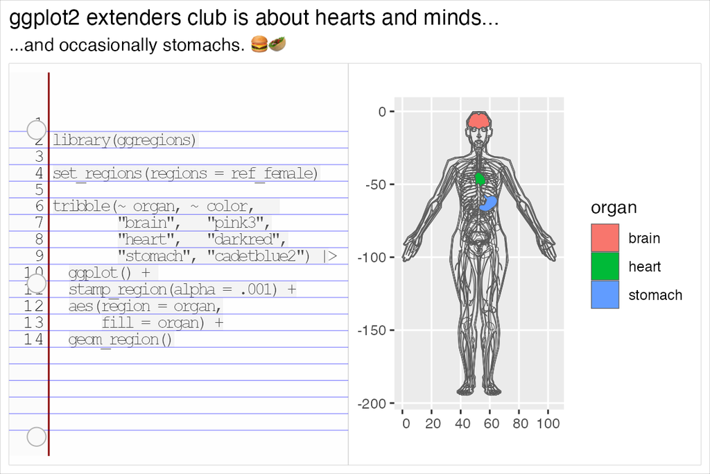

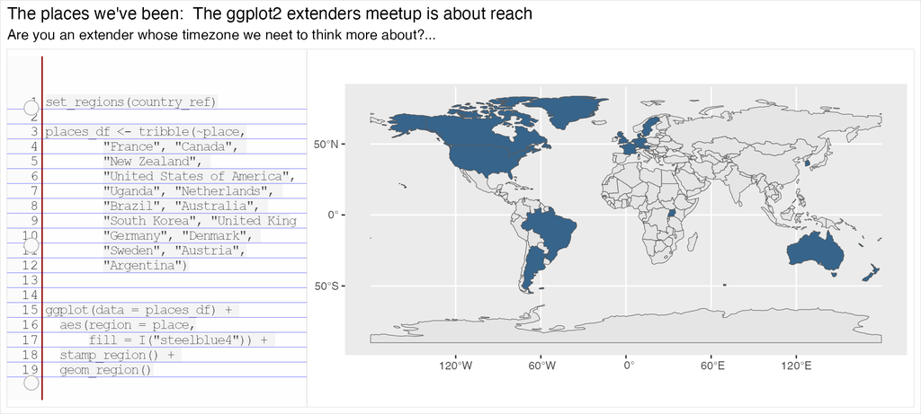

```r
last_plot() +
  geom_point(data = layer_data(), aes(x = x, y = y), shape = "|")
```

```r
knitr::knit_exit()
```